# Journal

Mafer Bravo

09 agosto, 2021

## 0.1 Librerias

La base es la libreria seqtime https://github.com/MaferBravoGarcia/seqtime.

[Artículo](https://microbiomejournal.biomedcentral.com/articles/10.1186/s40168-018-0496-2) de Faust

Para instalarla:

```r
library(devtools)
install_github("hallucigenia-sparsa/seqtime")
library(seqtime)
```

## 0.2 Matriz

**porcentaje edges positivos (pep)** : En el paper reportan edges negativos 70% para sujeto A y 63% para B. Usaré 10% de pep, para que no me salgan tan altos & sea error.

**conectance (c)**: Usaré el 0.05, valor más cercano para food network & dentro del rango inferido para microbial net.

```r
#N: No. de especies
N = 10
pep = 10
conec = 0.05

A = generateA(N,"klemm", pep = pep, c = conec)
```

```
## [1] "Adjusting connectance to 0.05"
## [1] "Initial edge number 80"
## [1] "Initial connectance 0.777777777777778"
## [1] "Number of edges removed 66"
## [1] "Final connectance 0.0444444444444444"
## [1] "Final connectance: 0.0444444444444444"
## [1] "Initial edge number 14"
## [1] "Initial connectance 0.0444444444444444"
## [1] "Number of negative edges already present: 10"
## [1] "Converting 3 edges into negative edges"
## [1] "Final connectance: 0.0444444444444444"
## [1] "Final arc number (excluding self-arcs) 4"
## [1] "Final negative arc number (excluding self-arcs) 3"
## [1] "PEP: 25"
```

## 0.3 Modelos

### 0.3.1 Modelos del [Artículo](https://microbiomejournal.biomedcentral.com/articles/10.1186/s40168-018-0496-2) de Faust

#### 0.3.1.1 Ricker

Revisar lo de K, en el artículo dice que la capacidad de carga es una distribución uniforme de 0 a 0.5.

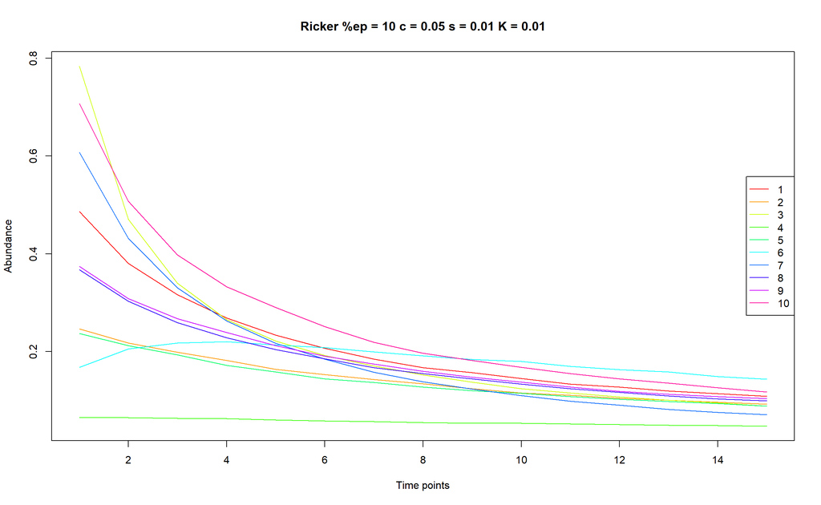

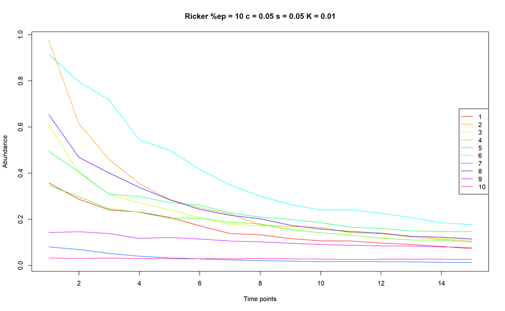

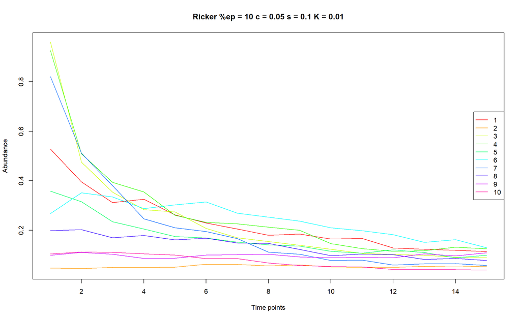

```r
#tiempo
tend = 15
#noise, término de fuerza
sigm = c(0.01,0.05,0.1)
#capacidad de carga
cap = 0.01

for (sig in sigm) {
  rickerplot=tsplot(ricker(N,A=A,K=rep(cap,N), tend=tend, sigma = sig), main = paste("Ricker", "%ep =", pep, "c =", conec, "σ =", sig, "K =", cap), legend = TRUE )
}
```

**GUARDAR** `setwd("~/Microtesis/Tesis1/03.OUTPUT/PLOTS/RICKER/")`

**RData** `save(rickerplot, file = paste("Ricker", "N =", N, "Tiempo = ", tend, "pep =", pep, "c =", conec, "sigma =", sig, "K =", cap,".RData"))`

**PDF** `pdf(paste("Ricker", "N =", N, "Tiempo = ", tend, "pep =", pep, "c =", conec, "sigma =", sig, "K =", cap, ".pdf"))`

#### 0.3.1.2 gLV

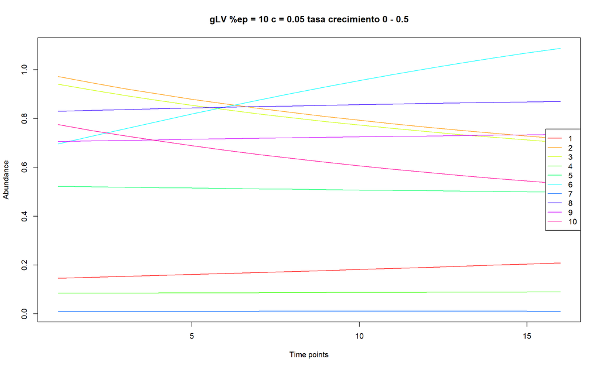

```r
tend = 1.5
grmin = 0
grmax = 0.5


glvplot=tsplot(glv (N, A=A, tend=tend, b = runif(N, min = grmin, max = grmax)), main = paste("gLV", "%ep =", pep, "c =", conec, "tasa crecimiento", grmin, "-", grmax), legend = TRUE )
```

**GUARDAR** `setwd("~/Microtesis/Tesis1/03.OUTPUT/PLOTS/gLV/")`

**RData** `save(glvplot, file = paste("gLV", "N =", N, "Tiempo = ", tend, "pep =", pep, "c =", conec, "tasa crecimiento", grmin, "-", grmax,".RData"))`

**PDF** `pdf(paste("gLV", "N =", N, "Tiempo = ", tend, "pep =", pep, "c =", conec, "tasa crecimiento", grmin, "-", grmax, ".pdf"))`

#### 0.3.1.3 SOI

¿Cuántos individuos poner?

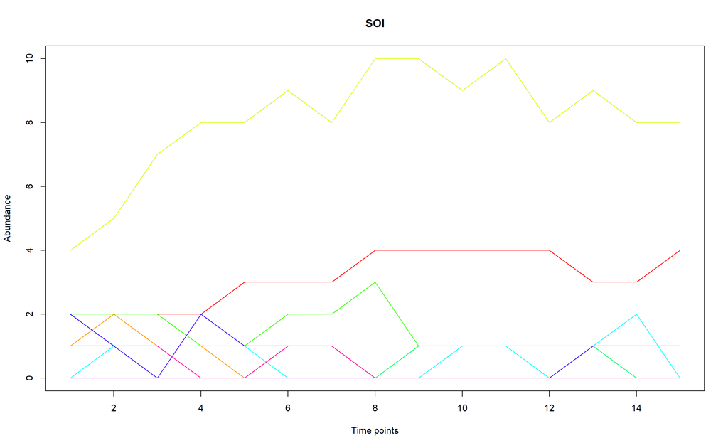

```r
soiplot=tsplot(soi(N, A=A, I=20, tend=15), main= "SOI")
```

**GUARDAR** `setwd("~/Microtesis/Tesis1/03.OUTPUT/PLOTS/")` `save(soiplot, file = "Soi.RData")`

#### 0.3.1.4 HUBBELL

¿Qué poner en metacomunidad?

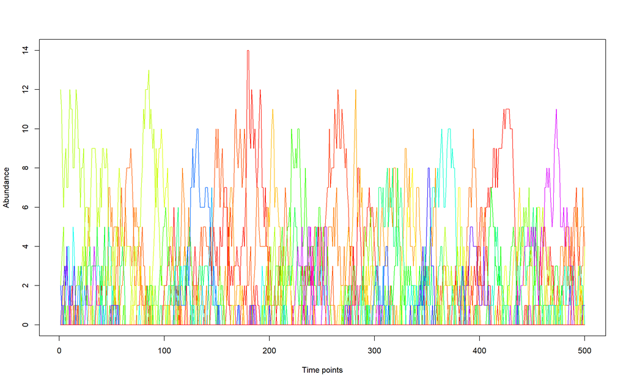

```r
M = 100
metapop <- generateAbundances(N = M, mode = 5, probabs = TRUE)
hubplot = tsplot(simHubbell(N = N, M = M, I = 20, d = N, m=0.1,  m.vector = metapop, tskip=500, tend=1000))
```

**GUARDAR** `setwd("~/Microtesis/Tesis1/03.OUTPUT/PLOTS/")` `save(hubplot, file = "Hubbell.RData")`